# fRagmentomics: A Per-Fragment Analysis Workflow

Killian Maudet, Yoann Pradat, Juliette Samaniego and Elsa Bernard

Gustave Roussy

killian.maudet@gustaveroussy.fr  
yoann.pradat@gustaveroussy.fr  
juliette.samaniego@gustaveroussy.fr  
elsa.bernard@gustaveroussy.fr

2025-09-12

#### Package

fRagmentomics 0.2.8

# 1 Introduction

[figure not shown]

Plasma circulating cell-free DNA (cfDNA) analysis has transformed cancer care. While recent work has shown that ctDNA fragments have distinct features (size, end motifs) compared to healthy cfDNA, few tools offer a standardized framework for an in-depth analysis that links these features to the specific mutational status of each DNA fragment.

**fRagmentomics** addresses this need by providing a robust and flexible R package to integrate cfDNA fragment features with their mutational status. By standardizing the analysis of both SNVs and indels at the single-fragment level, fRagmentomics supports the interpretation of liquid biopsies to distinguish tumoral origin.

This vignette provides a step-by-step walkthrough of the main analysis workflow using the `analyze_fragments()` function and demonstrates the package’s core visualization capabilities thank to the visualisation functions: `plot_size_distribution()`, `plot_qqseqlogo_meme()`, `plot_freq_barplot()`, `plot_motif_barplot()`.

# 2 Installation

To run this vignette, you will need the `fRagmentomics` package and its dependencies installed.

```r
# This command, from the README, installs all necessary dependencies
if (!requireNamespace("BiocManager", quietly = TRUE)) {
  install.packages("BiocManager")
}

BiocManager::install("ElsaB-Lab/fRagmentomics")
```

# 3 A Complete Analysis Workflow

To make it user-friendly, the entire analysis is performed by a single function: `analyze_fragments()`. We will use the example data included with the package to demonstrate a typical workflow.

For a deeper dive into the package’s methodology, please refer to the `README.md` file on the project’s [GitHub repository](https://github.com/ElsaB-Lab/fRagmentomics).

The README provides detailed explanations of: * The normalization for converting indel representations into a standardized VCF format. * The context-aware algorithm for determining read status. * The formulas used for precise fragment size calculation. * The logic for classifying fragments into different mutational groups.

## 3.1 1. Loading the Package and Example Data

First, we load the `fRagmentomics` library. The package includes a small BAM file, a corresponding FASTA reference, and a list of mutations to make testing easy.

```r
library(fRagmentomics)

# Locate the example files bundled with the package
mut_file <- system.file(
  "testdata/mutations", "mutations_cfdna-test-01_chr17_7576000_7579000.tsv",
  package = "fRagmentomics"
)
bam_file <- system.file(
  "testdata/bam", "cfdna-test-01_chr17_7576000_7579000.bam",
  package = "fRagmentomics"
)
fasta_file <- system.file(
  "testdata/fasta/hg19", "hg19_chr17_7576000_7579000.fa",
  package = "fRagmentomics"
)

# Print the file paths to confirm they were found
print(mut_file)
```

```
#> [1] "/root/project/fRagmentomics/inst/testdata/mutations/mutations_cfdna-test-01_chr17_7576000_7579000.tsv"
```

```r
print(bam_file)
```

```
#> [1] "/root/project/fRagmentomics/inst/testdata/bam/cfdna-test-01_chr17_7576000_7579000.bam"
```

```r
print(fasta_file)
```

```
#> [1] "/root/project/fRagmentomics/inst/testdata/fasta/hg19/hg19_chr17_7576000_7579000.fa"
```

To handle 0-based mutation coordinates, set the `one_based = FALSE` parameter. This will ensure the positions are correctly converted. Furthermore, `fRagmentomics` automatically standardizes indel representations to resolve ambiguities, as the same variant can often be described in multiple ways (e.g., left-aligned vs. right-aligned).

The following table summarizes the accepted formats:

**Simple Format**

| To describe a… | `REF` Column | `ALT` Column | `POS` Column |
| --- | --- | --- | --- |
| Deletion of **“AT”** | `AT` | `""`, `-`, `.`, `_`, `NA` | Position of the first deleted base (`A`) |
| Insertion of **“CT”** | `""`, `-`, `.`, `_`, `NA` | `CT` | Position of the base *before* the insertion |

**VCF-Style Padded Format**

| To describe a… | `REF` Column | `ALT` Column | `POS` Column |
| --- | --- | --- | --- |
| Deletion of **“AT”** from “G**AT**” | `GAT` | `G` | Position of the anchor base (`G`) |
| Insertion of **“CT**” after “A” | `A` | `ACT` | Position of the anchor base (`A`) |

## 3.2 2. Running the Analysis

### 3.2.1 Basic Workflow

First, we will run `analyze_fragments()` with the default arguments. We provide the paths to our three input files, a `sample_id` for annotation, and specify the number of cores for parallel processing.

```r
# Run the full analysis pipeline with default settings
results_df_basic <- analyze_fragments(
  mut = mut_file,
  bam = bam_file,
  fasta = fasta_file,
  sample_id = "cfdna-test-01",
  n_cores = 2
)
```

```
#> Reference allele matches FASTA
#> Processing bcftools norm normalisation for variant: chr17:2191 T>C
#> Reference allele matches FASTA
#> Processing bcftools norm normalisation for variant: chr17:2272 T>G
#> Reference allele matches FASTA
#> Processing bcftools norm normalisation for variant: chr17:1143 C>T
#> Reference allele matches FASTA
#> Processing bcftools norm normalisation for variant: chr17:2407 C>T
```

```r
# View the dimensions and the first few rows
cat("Dimensions of basic results:", dim(results_df_basic), "\n")
```

```
#> Dimensions of basic results: 2297 30
```

```r
head(results_df_basic)
```

```
#>   Chromosome Position Ref Alt Input_Mutation Fragment_Id Fragment_QC
#> 1      chr17     2191   T   C chr17:2191:T-C  READ_04015          OK
#> 2      chr17     2191   T   C chr17:2191:T-C  READ_03748          OK
#> 3      chr17     2191   T   C chr17:2191:T-C  READ_02659          OK
#> 4      chr17     2191   T   C chr17:2191:T-C  READ_01619          OK
#> 5      chr17     2191   T   C chr17:2191:T-C  READ_04516          OK
#> 6      chr17     2191   T   C chr17:2191:T-C  READ_00280          OK
#>   Fragment_Status_Simple Fragment_Status_Detail Fragment_Size Read_5p_Status
#> 1         NON-TARGET MUT                     WT           299           <NA>
#> 2         NON-TARGET MUT                     WT           300           <NA>
#> 3         NON-TARGET MUT                     WT           190           <NA>
#> 4         NON-TARGET MUT                     WT           177           <NA>
#> 5         NON-TARGET MUT                     WT           173           <NA>
#> 6         NON-TARGET MUT                     WT           309           <NA>
#>   Read_3p_Status FLAG_5p FLAG_3p MAPQ_5p MAPQ_3p BASE_5p BASE_3p BASQ_5p
```

[output cut: 20 more lines]

### 3.2.2 Advanced Workflow: Customizing the Analysis

The `analyze_fragments()` function can be customized for more specific use cases. In the example below, we will perform a more stringent analysis and request additional information in the output table.

Specifically, we will: * **Narrow the search window** to 1000 bp around the variant using `neg_offset_mate_search` and `pos_offset_mate_search`. * **Apply stricter BAM filters** by requiring reads to be in a “proper pair” using `flag_bam_list`. * **Request additional output columns** for template length (`report_tlen`), soft-clip counts (`report_softclip`), and the 3-base motifs at the fragment ends (`report_5p_3p_bases_fragment`).

```r
# Run the analysis with custom parameters
results_df_advanced <- analyze_fragments(
  mut = mut_file,
  bam = bam_file,
  fasta = fasta_file,
  sample_id = "cfdna-test-01",
  neg_offset_mate_search = -500,
  pos_offset_mate_search = 500,
  flag_bam_list = list(
    isProperPair = TRUE,
    isUnmappedQuery = FALSE,
    isSecondaryAlignment = FALSE,
    isDuplicate = FALSE
  ),
  report_tlen = TRUE,
  report_softclip = TRUE,
  report_5p_3p_bases_fragment = 3,
  n_cores = 2
)
```

```
#> Reference allele matches FASTA
#> Processing bcftools norm normalisation for variant: chr17:2191 T>C
#> Reference allele matches FASTA
#> Processing bcftools norm normalisation for variant: chr17:2272 T>G
#> Reference allele matches FASTA
#> Processing bcftools norm normalisation for variant: chr17:1143 C>T
#> Reference allele matches FASTA
#> Processing bcftools norm normalisation for variant: chr17:2407 C>T
```

```r
# Observe that stricter filtering may result in fewer fragments
cat("Dimensions of advanced results:", dim(results_df_advanced), "\n")
```

```
#> Dimensions of advanced results: 1998 33
```

```r
# View the newly added columns
library(dplyr)
results_df_advanced %>%
  select(Fragment_Id, TLEN, Nb_Fragment_Bases_Softclip_5p, Fragment_Bases_5p) %>%
  head()
```

```
#>   Fragment_Id TLEN Nb_Fragment_Bases_Softclip_5p Fragment_Bases_5p
#> 1  READ_02659  190                             0               TAA
#> 2  READ_01619  177                             0               TTT
#> 3  READ_04516  173                             0               CAA
#> 4  READ_04638  169                             0               TGC
#> 5  READ_04147  168                             0               GTT
#> 6  READ_04377  158                             0               AAC
```

## 3.3 3. Exploring the Output

**Note**: The following outputs and visualizations are generated from a small, simulated test dataset. They are intended to demonstrate the package’s functionality and are not representative of real biological results.

The `analyze_fragments()` function returns a `data.frame` where each row represents the analysis of a single fragment. Let’s explore the key columns to understand the results.

### 3.3.1 A First Look at the Results Table

A great way to get an overview of all the columns and their data types is to use `dplyr::glimpse()`.

```r
# Load dplyr to use glimpse()
library(dplyr)
glimpse(results_df_basic)
```

```
#> Rows: 2,297
#> Columns: 30
#> $ Chromosome             <chr> "chr17", "chr17", "chr17", "chr17", "chr17", "c…
#> $ Position               <int> 2191, 2191, 2191, 2191, 2191, 2191, 2191, 2191,…
#> $ Ref                    <chr> "T", "T", "T", "T", "T", "T", "T", "T", "T", "T…
#> $ Alt                    <chr> "C", "C", "C", "C", "C", "C", "C", "C", "C", "C…
#> $ Input_Mutation         <chr> "chr17:2191:T-C", "chr17:2191:T-C", "chr17:2191…
#> $ Fragment_Id            <chr> "READ_04015", "READ_03748", "READ_02659", "READ…
#> $ Fragment_QC            <chr> "OK", "OK", "OK", "OK", "OK", "OK", "OK", "OK",…
#> $ Fragment_Status_Simple <chr> "NON-TARGET MUT", "NON-TARGET MUT", "NON-TARGET…
#> $ Fragment_Status_Detail <chr> "WT", "WT", "WT", "WT", "WT", "WT", "WT", "WT",…
#> $ Fragment_Size          <dbl> 299, 300, 190, 177, 173, 309, 169, 277, 168, 15…
#> $ Read_5p_Status         <chr> NA, NA, NA, NA, NA, NA, NA, NA, NA, NA, NA, NA,…
#> $ Read_3p_Status         <chr> "WT", "WT", "WT", "WT", "WT", "WT", "WT", "WT",…
#> $ FLAG_5p                <int> 97, 161, 163, 99, 99, 97, 99, 161, 163, 163, 16…
```

[output cut: 17 more lines]

### 3.3.2 Understanding the Fragment Status

The most important columns for interpreting the results are `Fragment_Status_Simple` and `Fragment_Status_Detail`.

The **`Fragment_Status_Simple`** column provides a high-level classification for each fragment. The table below explains each possible label:

| `Fragment_Status_Simple` | Represents… | Typical Read Evidence (`Read_5p_Status` / `Read_3p_Status`) |
| --- | --- | --- |
| **`MUT`** | The fragment confidently supports the **mutant allele**. | `MUT`/`MUT`, `MUT`/`AMB` or `MUT`/`NA` |
| **`NON-TARGET MUT`** | The fragment confidently supports an allele that is **not the target**. | `WT`/`WT`, `WT`/`AMB`, `WT`/`NA`, `OTH`/`OTH`, `OTH`/`AMB`, `OTH`/`NA`, or `WT`/`OTH` |
| **`DISCORDANT`** | The two reads give **conflicting** high-confidence information. | `MUT`/`WT` or `MUT`/`OTH` |
| **`AMB`** | The evidence is **ambiguous**; a confident call cannot be made. | `AMB`/`AMB`, `AMB`/`NA` |

You can quickly summarize the results for a given mutation by counting the occurrences of each status:

```r
results_df_advanced %>%
  count(Fragment_Status_Simple)
```

```
#>   Fragment_Status_Simple    n
#> 1             DISCORDANT    1
#> 2                    MUT  148
#> 3         NON-TARGET MUT 1849
```

The **`Fragment_Status_Detail`** column concatenates the statuses of the two reads (e.g., `"WT & AMB"`).

```r
results_df_advanced %>%
  count(Fragment_Status_Detail)
```

```
#>                 Fragment_Status_Detail    n
#> 1                                  MUT  147
#> 2 MUT & MUT but potentially larger MUT    1
#> 3  MUT but potentially larger MUT & WT    1
#> 4                                  OTH    2
#> 5                             OTH & WT    8
#> 6                                   WT 1839
```

### 3.3.3 Exploring Other Key Features

You can also quickly summarize other key fragmentomic features like the calculated **fragment size**:

```r
summary(results_df_advanced$Fragment_Size)
```

```
#>    Min. 1st Qu.  Median    Mean 3rd Qu.    Max.
#>    82.0   151.0   163.0   162.5   172.0   329.0
```

And you can easily extract the final **VAF** calculated for each mutation:

```r
results_df_advanced %>%
  distinct(VAF)
```

```
#>          VAF
#> 1  0.2873563
#> 2  0.1968504
#> 3 25.8652095
#> 4  0.6756757
```

For a complete description of every column in the output, please refer to the `README.md` file on the package’s [GitHub repository](https://github.com/ElsaB-Lab/fRagmentomics).

# 4 Visualizing Fragmentomic Features

The `results_df_advanced` object, produced by `analyze_fragments()`, can be directly used with the package’s suite of plotting functions to visualize the results.

## 4.1 Fragment Size Distribution

One of the most common analyses is to compare the size distribution of fragments that carry the mutation (`MUT`) against those that do not (`NON-TARGET MUT`). The `plot_size_distribution()` function is designed for this purpose.

### 4.1.1 **1. Comparing Groups with a Histogram**

Let’s start by creating a histogram to compare our two main groups. We’ll set `show_histogram = TRUE` and `show_density = FALSE`. Using `histo_args` to set an `alpha` value adds transparency, which is helpful when bars overlap.

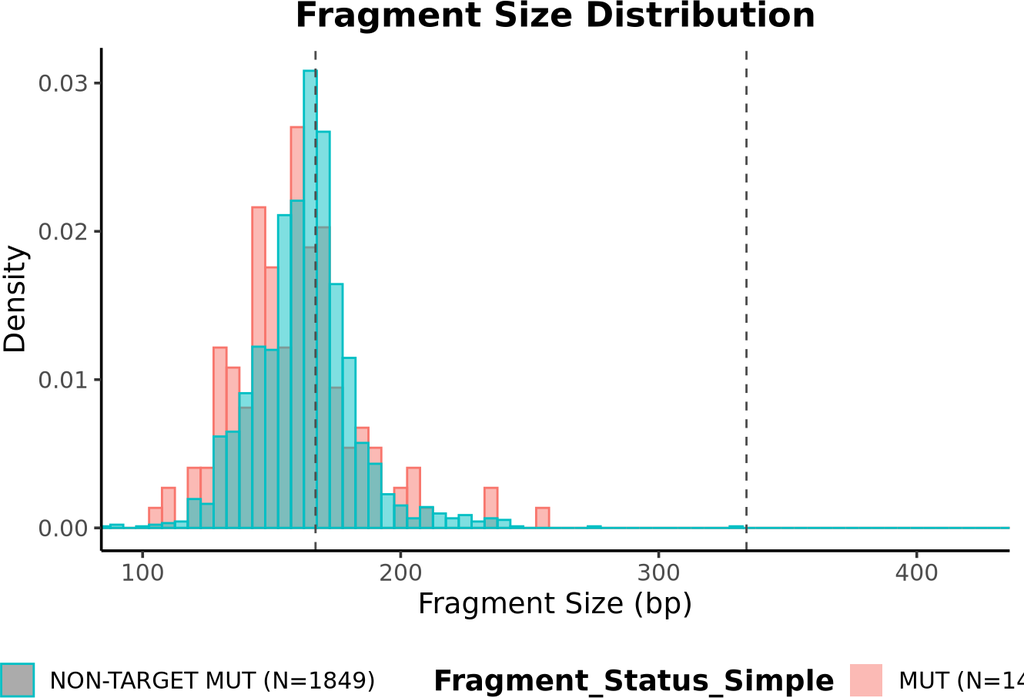

(#fig:plot_size_histogram)Histogram comparing the fragment size distribution of MUT and NON-TARGET MUT fragments.

```r
plot_size_distribution(
  df_fragments = results_df_advanced,
  vals_z = c("MUT", "NON-TARGET MUT"),
  show_histogram = TRUE,
  show_density = FALSE,
  x_limits = c(100, 420),
  histo_args = list(alpha = 0.5)
)
```

### 4.1.2 **2. Using Density Curves**

Alternatively, we can represent the same data using smooth density curves, which can make it easier to see the shape and peaks of the distributions. This is the default behavior (`show_density = TRUE`). Here, we’ll also show all available groups in the data by leaving `vals_z` as the default `NULL`.

```
#> Note: Groups with fewer than 2 data points were removed as they cannot be plotted.
```

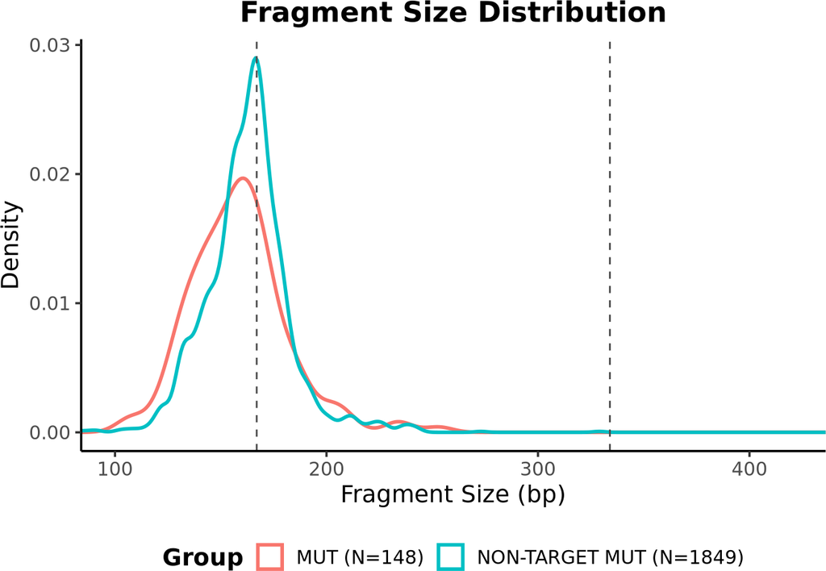

(#fig:plot_size_density)Density plot comparing the fragment size distribution of all available status groups.

```r
plot_size_distribution(
  df_fragments = results_df_advanced,
  show_histogram = FALSE,
  show_density = TRUE,
  x_limits = c(100, 420)
)
```

### 4.1.3 **3. Visualizing the Overall Distribution**

Finally, to see the size distribution of all fragments combined into a single group, we can set `col_z = NULL`. This example also demonstrates how to overlay a histogram and a density curve in the same plot.

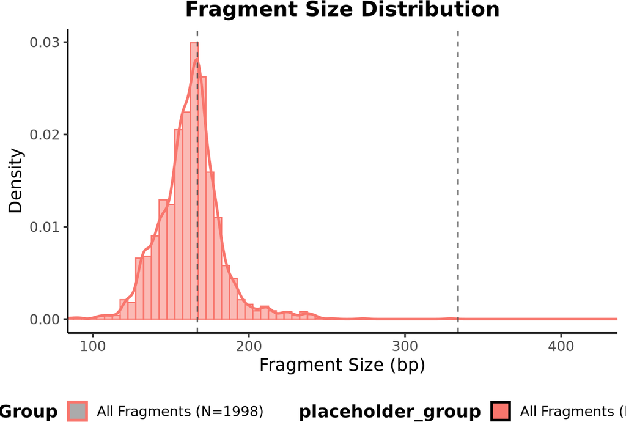

(#fig:plot_size_ungrouped)Overall fragment size distribution for all fragments, shown as a combined histogram and density plot.

```r
plot_size_distribution(
  df_fragments = results_df_advanced,
  col_z = NULL,
  show_histogram = TRUE,
  show_density = TRUE,
  x_limits = c(100, 420),
  histo_args = list(alpha = 0.5)
)
```

## 4.2 Detailed 3-Base End Motif Proportions

For a deeper dive into the 3-base motifs at fragment ends, the package provides `plot_motif_barplot()`. This function has three visualization modes, controlled by the `representation` argument.

### 4.2.1 1. Hierarchical View (`representation = "split_by_base"`)

This is the default view. It creates a detailed plot with nested facets for each base position, providing a complete landscape of all 64 possible motif proportions.

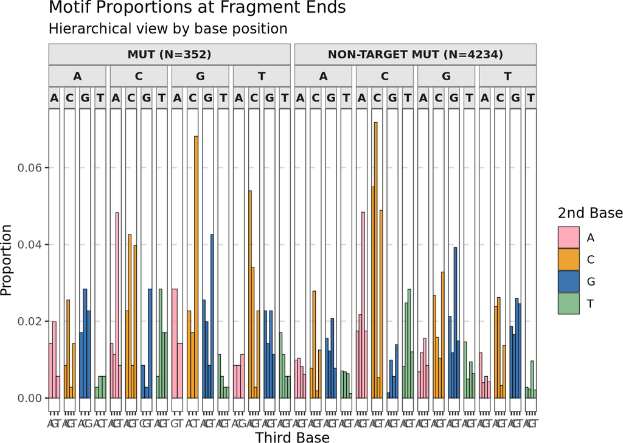

(#fig:plot_motif_hierarchical)Hierarchical view of 3-base motif proportions for MUT and NON-TARGET MUT groups.

```r
plot_motif_barplot(
  df_fragments = results_df_basic,
  representation = "split_by_base",
  vals_z = c("MUT", "NON-TARGET MUT")
)
```

We can also customize this plot, for instance by filtering to show only motifs that start with ‘C’ or ‘G’ using `motif_start`, and passing additional arguments (like `alpha` for transparency) to the underlying `geom_bar()` via the `...` parameter.

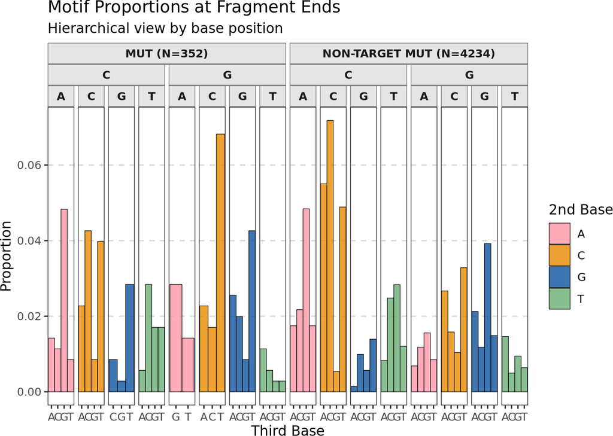

(#fig:plot_motif_hierarchical_custom)A customized hierarchical plot filtered for specific starting bases.

```r
plot_motif_barplot(
  df_fragments = results_df_basic,
  representation = "split_by_base",
  motif_start = c("C", "G"),
  vals_z = c("MUT", "NON-TARGET MUT"),
  alpha = 0.7 # Pass 'alpha' to geom_bar()
)
```

### 4.2.2 2. Differential Analysis (`representation = "differential"`)

This mode is designed to directly compare **exactly two groups**. It calculates the log2 Fold Change (log2FC) of the proportion of each motif between the groups, making it easy to spot motifs that are enriched or depleted in one group relative to the other.

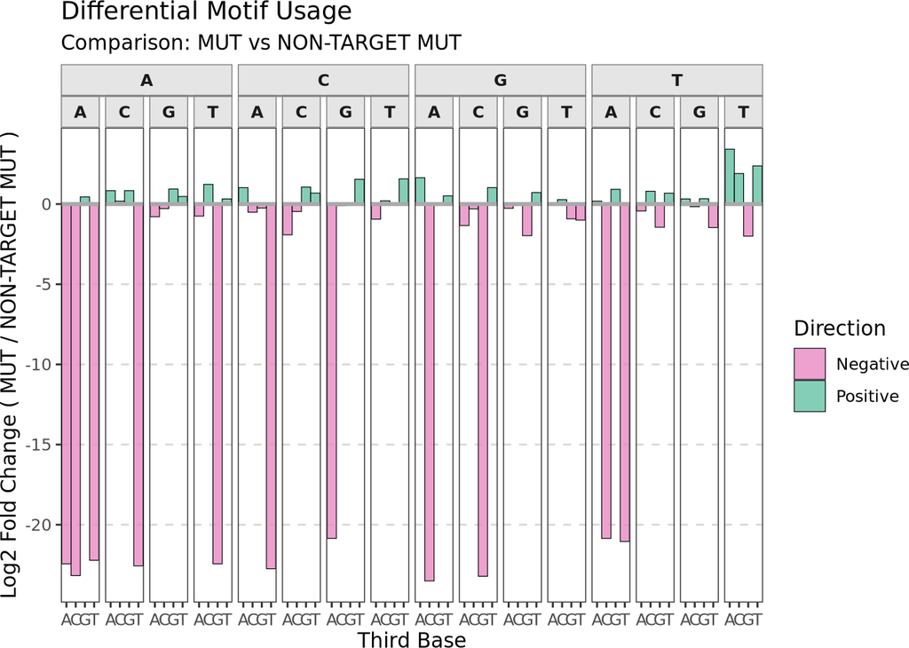

(#fig:plot_motif_differential)Differential analysis showing the log2 Fold Change of motif usage between MUT and NON-TARGET MUT groups.

```r
plot_motif_barplot(
  df_fragments = results_df_advanced,
  representation = "differential",
  vals_z = c("MUT", "NON-TARGET MUT")
)
```

### 4.2.3 3. Side-by-side Comparison (`representation = "split_by_motif"`)

This mode creates a more traditional bar chart. Each 3-base motif is placed on the x-axis, with side-by-side bars showing the proportion for each group. This is useful for directly comparing the frequency of specific, known motifs.

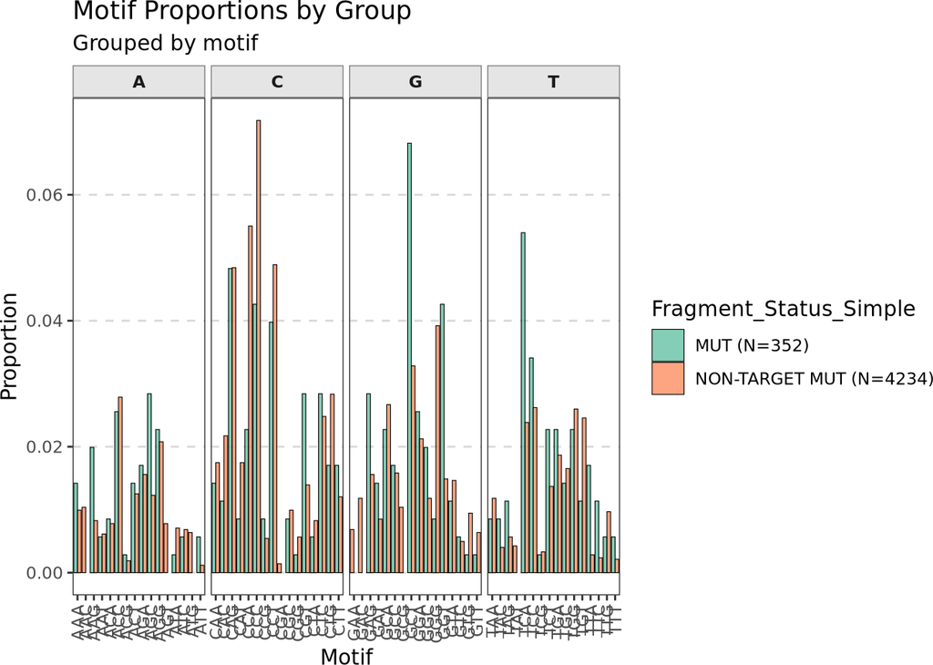

(#fig:plot_motif_side_by_side)Side-by-side comparison of motif proportions.

```r
plot_motif_barplot(
  df_fragments = results_df_basic,
  representation = "split_by_motif",
  vals_z = c("MUT", "NON-TARGET MUT")
)
```

### 4.2.4 End Motif Sequence Logos

To visualize the nucleotide frequency at each position of the fragment ends, the package provides `plot_qqseqlogo_meme()`. This function uses the popular `ggseqlogo` package to create sequence logo plots, which are excellent for identifying conserved patterns or sequence preferences.

#### 4.2.4.1 1. Comparing Motifs Between Groups

[figure not shown]

```r
plot_qqseqlogo_meme(
  df_fragments = results_df_basic,
  motif_type = "Start",
  motif_size = 6,
  vals_z = c("MUT", "NON-TARGET MUT")
)
```

#### 4.2.4.2 2. Visualizing Both Ends of a Single Group

You can also analyze a single group in more detail. By setting `motif_type = "Both"`, the function will display the 5’-end motif and the 3’-end motif side-by-side. Let’s look at the 4-base motifs for just the `MUT` fragments.

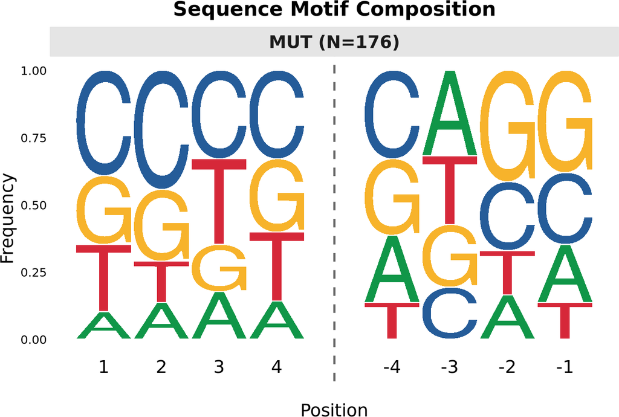

(#fig:plot_logo_single_group)Sequence logo showing the 4-base motifs from both the 5’ and 3’ ends for MUT fragments.

```r
plot_qqseqlogo_meme(
  df_fragments = results_df_basic,
  motif_type = "Both",
  motif_size = 4,
  vals_z = "MUT"
)
```

## 4.3 Overall Nucleotide Frequency

The `plot_freq_barplot()` function provides a summary of the nucleotide composition at fragment ends. Instead of looking at specific motifs, it calculates the overall proportion of each of the four bases (A, C, G, T) across the motif length. This is useful for spotting broad compositional biases between groups and includes a global Chi-squared test for statistical significance.

In this example, we will analyze the overall nucleotide frequency in the first 5 bases (`motif_size = 5`) of the 5’ end (`motif_type = "Start"`) of the fragments. We will also pass the `alpha` argument via `...` to make the bars transparent.

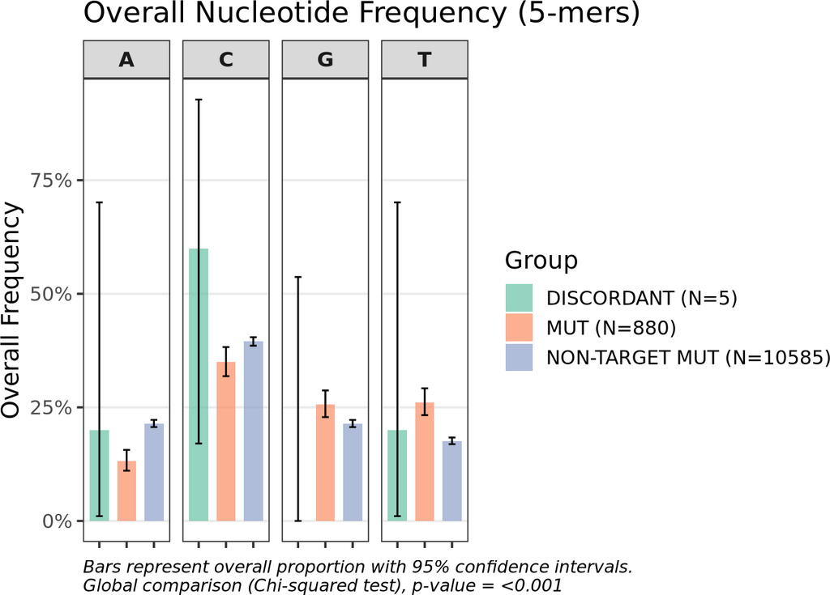

```r
plot_freq_barplot(
  df_fragments = results_df_basic,
  motif_size = 5,
  motif_type = "Start",
  alpha = 0.7
)
```

# 5 Session Information